# Seasonality of NMO and NMDA dischrage rates

Heather Kates

2023-02-08

1. Dataset summary and download
2. Basic data visualizations
3. Generalized linear models
   - 3.1 The effect of month on discharge rate
     - NMO
     - NMDA
   - 3.2 The effect of month on discharge counts
     - NMO
     - NMDA
4. Cosinor regression models (sinusoidal)
   - 4.1 Seasonality of discharge rate
     - NMO
     - NMDA
   - 4.2 Seasonality of discharge counts
     - NMO
     - NMDA
5. Decomposing the seasonal component of NMO/NMDA time series data + NMO + NMDA

## 1. Data set summary and download

The data is the monthly number of discharges that are coded as NMO or NMDA from October 2015 to January 2022. To assess the effect of month and season on discharge rate using generalized linear models, proportion dependent variables are created with the number of NMO codes or NMDA codes at discharge as the numerator and the total number of discharges is the denominator.

## 2.Visualizations of the NMO and NMDA discharge proportions over time as a line and boxplot.

These types of visualization do not consider the trend vs. seasonal components and may be misleading.

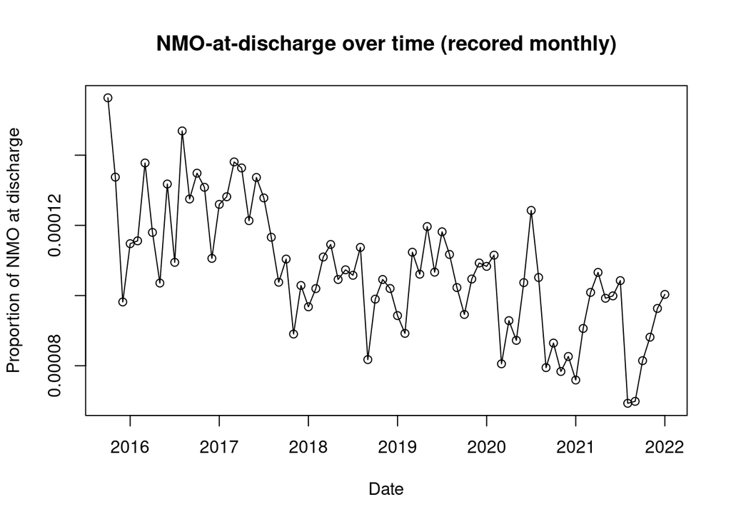

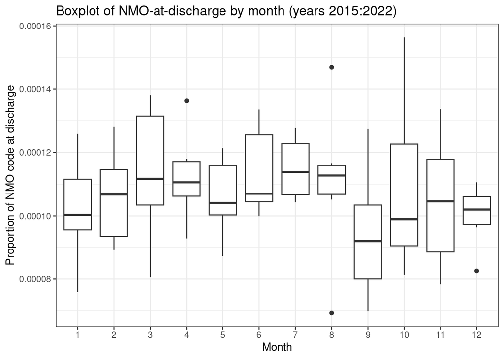

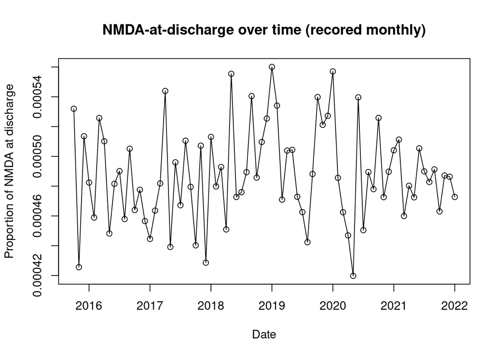

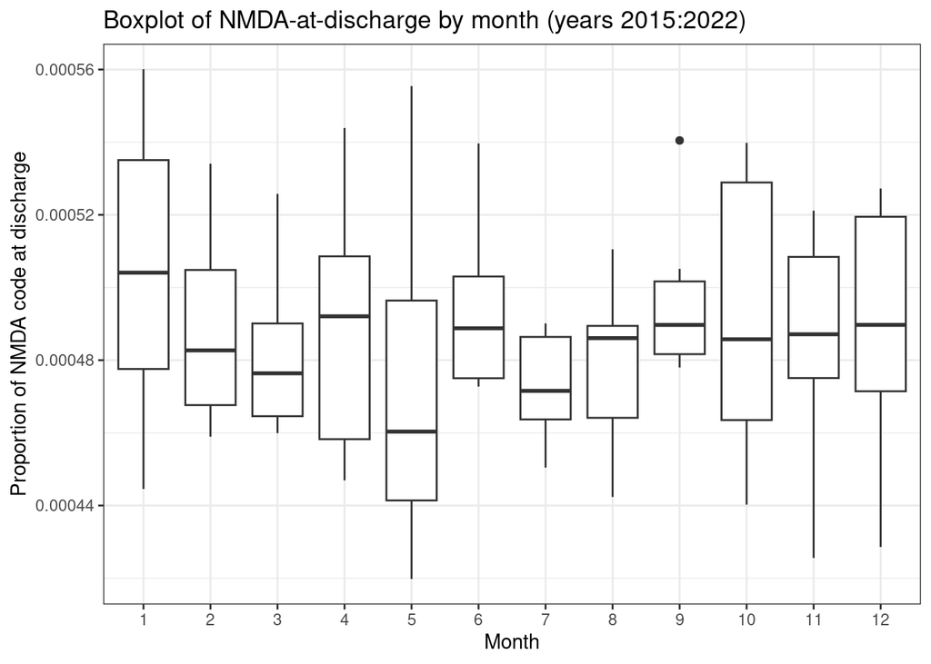

## 3. Generalized linear models to detect effect of month on NMO/NMDA discharge rate

### 3.1 The effect of month on discharge rate

We can first test for significance of the effect of month using generalized linear models. This is relevant if the seasonal pattern is not sinusoidal (and is probably not a good fit for seasonal data, but interesting to check nonetheless).

We use the formula: **NMO at discharge proportion ~ month**. We assume a quasibinomial distribution of the data because the dependent variable is a proportion and its variance is smaller than expected under a 0 to 1 binomial distribution.

|  | mean | lower | upper | zvalue | pvalue |
| --- | --- | --- | --- | --- | --- |
| monthsFeb | 0.1267 | -0.0631 | 0.3166 | 1.3082 | 0.1955 |
| monthsMar | 0.1029 | -0.0837 | 0.2896 | 1.081 | 0.2837 |
| monthsApr | 0.1266 | -0.0605 | 0.3137 | 1.3262 | 0.1895 |
| monthsMay | 0.0345 | -0.1555 | 0.2245 | 0.3557 | 0.7232 |
| monthsJun | 0.1392 | -0.0472 | 0.3257 | 1.4634 | 0.1483 |
| monthsJul | 0.1162 | -0.0698 | 0.3022 | 1.2246 | 0.2252 |
| monthsAug | 0.0773 | -0.1106 | 0.2652 | 0.8064 | 0.423 |
| monthsSep | -0.0511 | -0.2473 | 0.1451 | -0.5106 | 0.6114 |
| monthsOct | 0.0631 | -0.1183 | 0.2445 | 0.6822 | 0.4976 |
| monthsNov | 0.0508 | -0.1326 | 0.2342 | 0.5426 | 0.5893 |

[output cut: 1 more lines]

|  | mean | lower | upper | zvalue | pvalue |
| --- | --- | --- | --- | --- | --- |
| monthsFeb | 0.0578 | -0.0171 | 0.1326 | 1.5127 | 0.1353 |
| monthsMar | -0.0457 | -0.1209 | 0.0294 | -1.1938 | 0.237 |
| monthsApr | 0.0016 | -0.0733 | 0.0764 | 0.0409 | 0.9675 |
| monthsMay | -0.0647 | -0.1402 | 0.0108 | -1.68 | 0.0978 |
| monthsJun | 0.0124 | -0.0621 | 0.087 | 0.327 | 0.7447 |
| monthsJul | -0.0659 | -0.1414 | 0.0096 | -1.7099 | 0.0921 |
| monthsAug | -0.0532 | -0.1284 | 0.0221 | -1.3843 | 0.1711 |
| monthsSep | 0.0173 | -0.0572 | 0.0917 | 0.4541 | 0.6513 |
| monthsOct | -0.0239 | -0.0956 | 0.0478 | -0.6528 | 0.5162 |
| monthsNov | -0.0056 | -0.0776 | 0.0663 | -0.1535 | 0.8785 |

[output cut: 1 more lines]

### 3.2 The effect of month on discharge count

Another approach is to model the effect of month on the *number* of NMO or NMDA discharges (assuming a poisson distribution) while including the total number of discharges as a covariate:

**Number of NMO/NMDA discharges ~ month + Total Discharges per month**

|  | mean | lower | upper | zvalue | pvalue |
| --- | --- | --- | --- | --- | --- |
| monthsFeb | 1.0806 | 0.9543 | 1.2237 | 1.2225 | 0.2215 |
| monthsMar | 1.0946 | 0.9717 | 1.2331 | 1.4873 | 0.1369 |
| monthsApr | 1.093 | 0.9678 | 1.2344 | 1.4332 | 0.1518 |
| monthsMay | 1.0337 | 0.9158 | 1.1667 | 0.5363 | 0.5918 |
| monthsJun | 1.126 | 0.9991 | 1.2689 | 1.9453 | 0.0517 |
| monthsJul | 1.1325 | 1.0067 | 1.274 | 2.0703 | 0.0384 |
| monthsAug | 1.0791 | 0.9579 | 1.2156 | 1.2528 | 0.2103 |
| monthsSep | 0.929 | 0.8192 | 1.0535 | -1.1482 | 0.2509 |
| monthsOct | 1.0166 | 0.9045 | 1.1427 | 0.2769 | 0.7819 |
| monthsNov | 0.9921 | 0.8802 | 1.1182 | -0.13 | 0.8965 |

[output cut: 1 more lines]

|  | mean | lower | upper | zvalue | pvalue |
| --- | --- | --- | --- | --- | --- |
| monthsFeb | 1.075 | 1.0157 | 1.1377 | 2.4986 | 0.0125 |
| monthsMar | 0.9506 | 0.8993 | 1.0048 | -1.7913 | 0.0732 |
| monthsApr | 1.0031 | 0.948 | 1.0613 | 0.1058 | 0.9157 |
| monthsMay | 0.9433 | 0.8922 | 0.9972 | -2.057 | 0.0397 |
| monthsJun | 1.014 | 0.9595 | 1.0716 | 0.4922 | 0.6226 |
| monthsJul | 0.9264 | 0.8765 | 0.9792 | -2.7034 | 0.0069 |
| monthsAug | 0.9382 | 0.8879 | 0.9912 | -2.2736 | 0.023 |
| monthsSep | 1.016 | 0.9617 | 1.0735 | 0.5671 | 0.5706 |
| monthsOct | 0.967 | 0.9171 | 1.0196 | -1.2417 | 0.2144 |
| monthsNov | 1.0024 | 0.9498 | 1.058 | 0.0881 | 0.9298 |

[output cut: 1 more lines]

#### When we use the total number of NMO/NMDA discharges per month as the dependent variable and including the total monthly discharges as a covariate, some months differ from the reference month significantly.

## 4. Cosinor Regression Model for Detecting Seasonality in Yearly Data

A more realistic model for seasonal data is the cosinor model. The cosinor model consists of fitting a linear regression where the NMO or NMDA proportions are regressed onto a sine and a cosine term of transformations of the time variable. Taken together, the terms give a linear representation of a sine curve with amplitude and a phase, which can be used to describe a seasonal pattern.

### 4.1 The seasonality of discharge rate

To analyse the seasonal variation of the rate of NMO code at discharge, we fitted cosinor models to the proportion of discharges coded as NMO or NMDA, using month of measurement to represent time.

#### NMO discharge rate cosinor test does not find seasonality is significant

```
## Cosinor test:
## Number of observations = 76
## Amplitude = 0 (probability scale)
## Phase: Month = 4.9
## Low point: Month = 10.9
## Significant seasonality based on adjusted significance level of 0.025  =  FALSE
##
## Regression coefficients:
##                Estimate Std..Error      t.value      Pr...t..
## (Intercept) -9.14090281 0.01930574 -473.4811321 4.763084e-129
## cosw        -0.02358991 0.02729785   -0.8641673  3.903267e-01
## sinw         0.04520873 0.02731524    1.6550733  1.022030e-01
```

#### NMDA discharge rate cosinor test does not find seasonality is significant

```
## Cosinor test:
## Number of observations = 76
## Amplitude = 0 (probability scale)
## Phase: Month = 13
## Low point: Month = 7
## Significant seasonality based on adjusted significance level of 0.025  =  FALSE
##
## Regression coefficients:
##                  Estimate  Std..Error       t.value      Pr...t..
## (Intercept) -7.6264415692 0.008340818 -914.35174367 6.568095e-150
## cosw         0.0192711261 0.011780290    1.63587877  1.061697e-01
## sinw        -0.0000838852 0.011789212   -0.00711542  9.943422e-01
```

### 4.2 The seasonality of discharge count

As with the glm approach, we can fit the cosinor model using the *number* of NMO or NMDA discharges as the dependent variable while including the total number of discharges as a covariate.

When we do this, seasonality **is** significant

#### NMO discharge count cosinor test finds seasonality is significant

```
## Cosinor test:
## Number of observations = 76
## Amplitude = 3.46 (absolute scale)
## Phase: Month = 5.1
## Low point: Month = 11.1
## Significant seasonality based on adjusted significance level of 0.025  =  TRUE
##
## Regression coefficients:
##                             Estimate   Std..Error   z.value     Pr...z..
## (Intercept)             3.974626e+00 9.387391e-02 42.340050 0.000000e+00
## Total.Discharges.month  5.480509e-07 1.200292e-07  4.565980 4.971651e-06
## cosw                   -3.488795e-02 1.804619e-02 -1.933258 5.320438e-02
## sinw                    5.249786e-02 1.806905e-02  2.905403 3.667807e-03
```

#### NMDA discharge count cosinor test finds seasonality is significant

```
## Cosinor test:
## Number of observations = 76
## Amplitude = 2.74 (absolute scale)
## Phase: Month = 1.2
## Low point: Month = 7.2
## Significant seasonality based on adjusted significance level of 0.025  =  TRUE
##
## Regression coefficients:
##                            Estimate   Std..Error     z.value      Pr...z..
## (Intercept)            4.761122e+00 4.595678e-02 103.5999822  0.000000e+00
## Total.Discharges.month 1.500337e-06 5.804406e-08  25.8482455 2.546161e-147
## cosw                   2.306578e-02 8.368588e-03   2.7562337  5.847121e-03
## sinw                   2.480583e-03 8.443323e-03   0.2937922  7.689167e-01
```

## 5. Decomposing seasonal data

#### The above tests assumed either non-sinuoidal seasonality (glm) or symmetric and stationary sinusoidal seasonality (cosinor). We can also look at other patterns by isolating seasonal patterns from other effects.

A seasonal time series, in addition to the trend and random components, also has a seasonal component. Decomposing a seasonal time series means separating the time series into these three components to estimate the trend, seasonal, and random components of the NMO or NMDA discharge rates.

#### Decomposition of NMO discharge rate time series

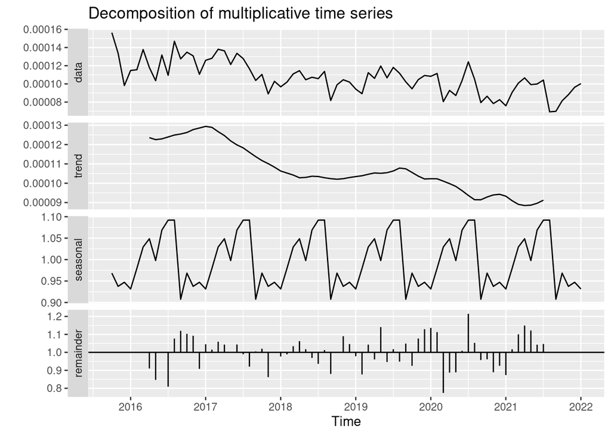

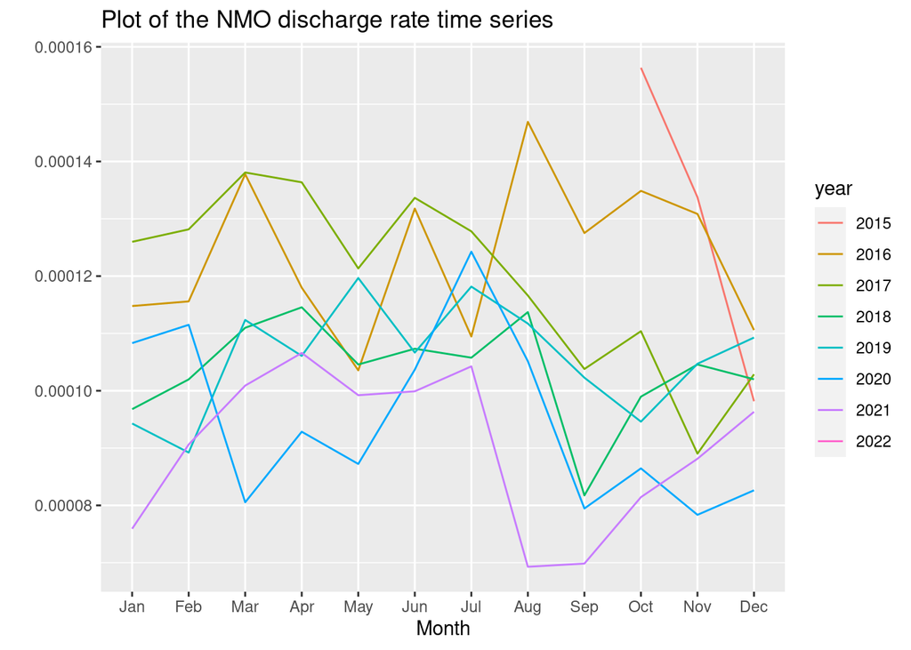

This makes a different line for each year: it then becomes easier to isolate patterns. There are two things we can now often answer: what are general patterns, and do those patterns persist over time?

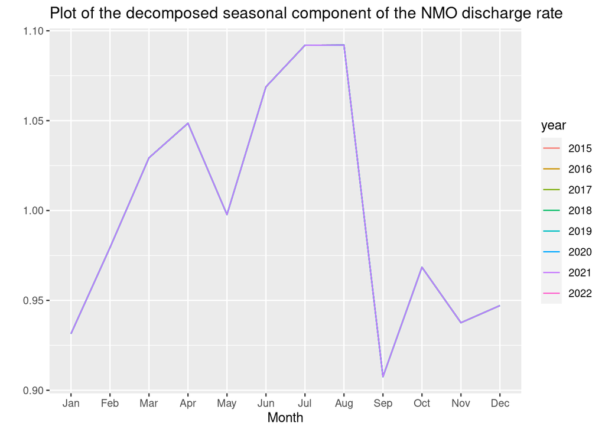

Above we visualize the seasonal plot of the decomposed seasonal component of the NMO discharge rate data.

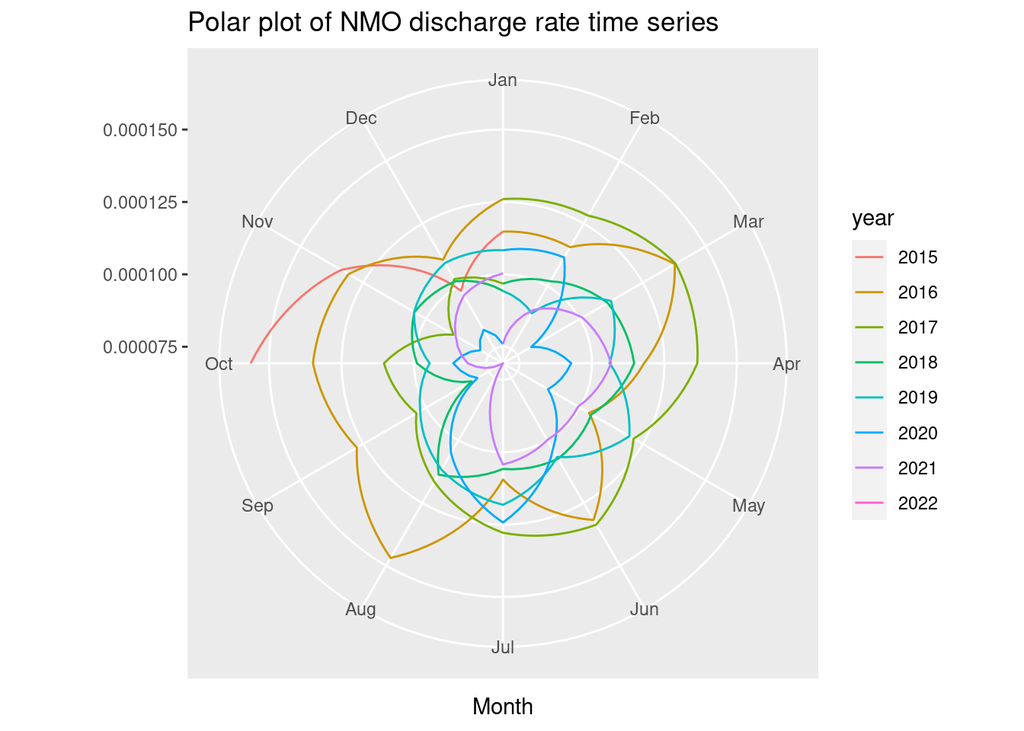

In this polar plot, if all (or many) single-year lines are together at a given month, we can see there is a year over year trend. It is not apparent here.

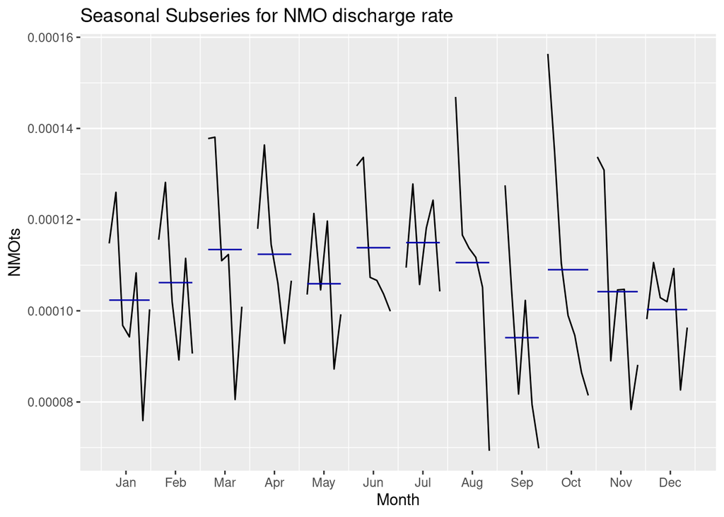

The seasonal subseries shows for each month, the evolution over years. The blue horizontal lines give the mean. This makes the evolution over time perhaps somewhat clearer than the original seasonal plot.

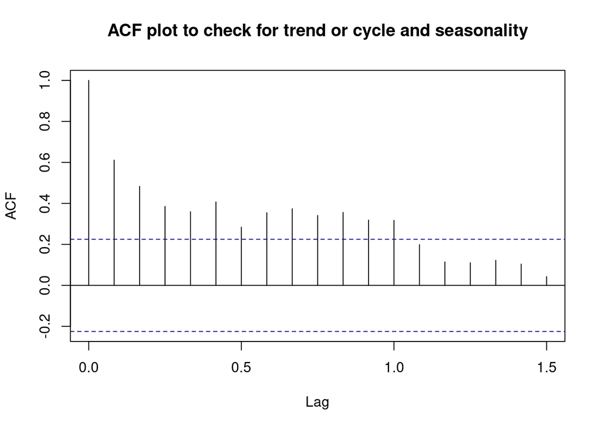

The ACF plot can be also be used to check for trend or cycle and seasonality. If the data has no trend or cycle then the ACF plot will show rapid decay, while if it has no repeated pattern then it does not have seasonality. Thus the ACF plots can be used to check for some violations of weak stationarity.

#### Decomposition of NMDA discharge rate time series

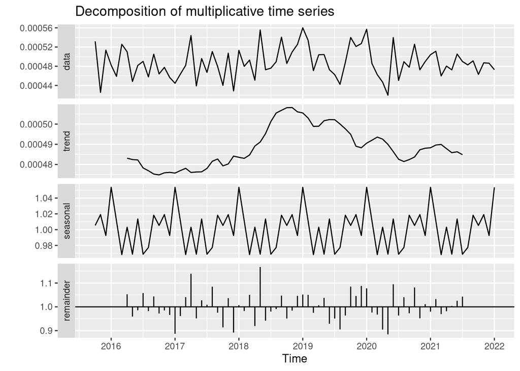

We can see several things. First, the trend-cycle is not linear. Secondly, the seasonal component seems to start each year high and then fall and rise several times. Third, the remainder appears to be random noise suggesting the decomposition captured the true seasonal component.

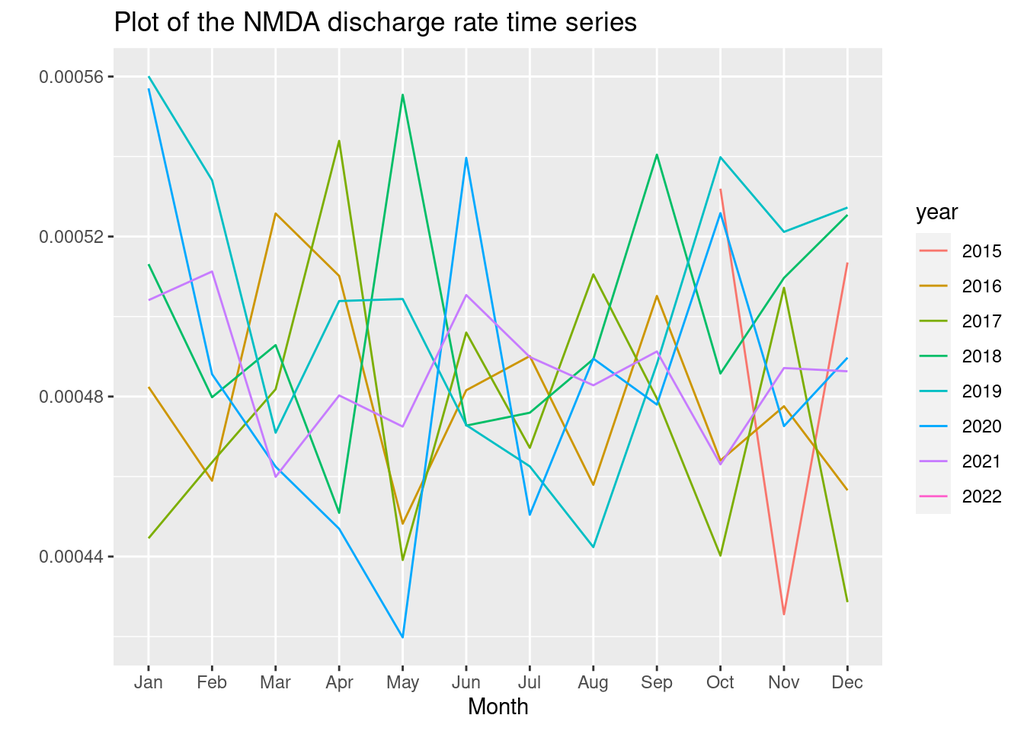

This makes a different line for each year: it then becomes easier to isolate patterns. There are two things we can now often answer: what are general patterns, and do those patterns persist over time?

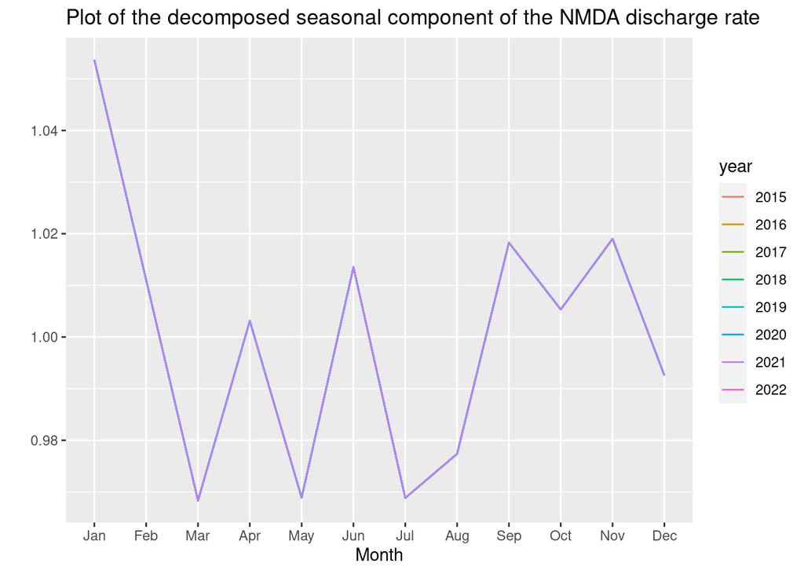

Above we visualize the seasonal plot of the decomposed seasonal component of the NMDA discharge rate data.

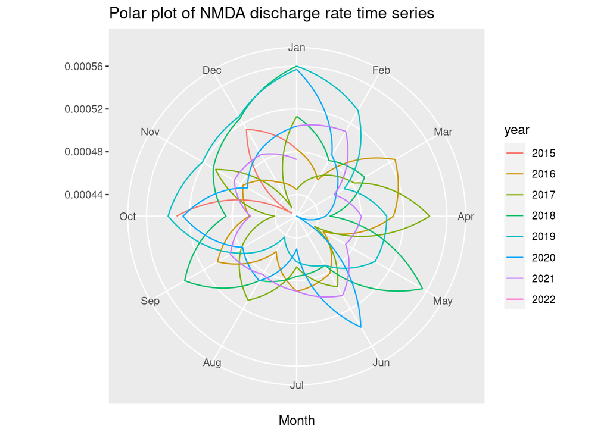

In this polar plot, if all (or many) single-year lines are together at a given month, we can see there is a year over year trend. It is not apparent here.

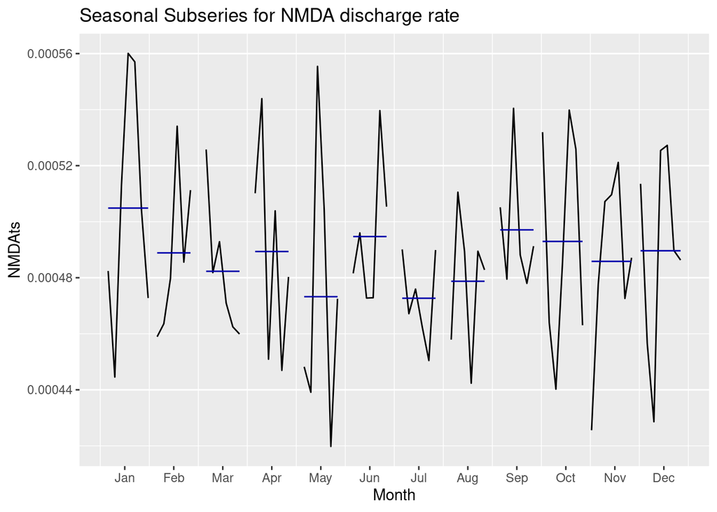

The seasonal subseries shows for each month, the evolution over years. The blue horizontal lines give the mean. This makes the evolution over time perhaps somewhat clearer than the original seasonal plot.

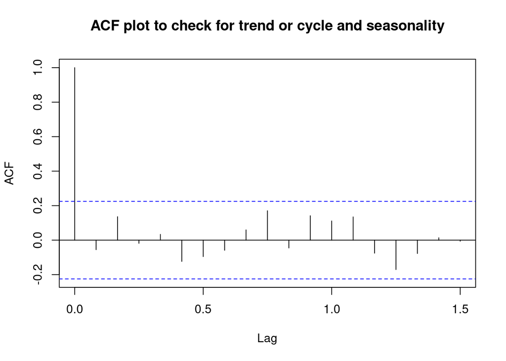